# Relatório 3 - Distribuições de Probabilidade

04/05/2022

## Objetivo

Nesse relatório, será abordado sobre as distribuições de proabalidade e como aplicá-las no ambiente R.

## Apresentação do relatório

Diante do objetivo do relatório, será apresentado nas próximas subseções, os pontos a serem discutidos.

## Introdução

Um experimento que pode gerar diferentes resultados se realizado mais de uma vez sob as mesmas condições é chamado de experimento aleatório. Alguns exemplos desses experimentos são:

- o lançamento de um dado;
- lançamentos consecutivos de uma moeda; e
- a observação da duração do tempo de um dispositivo eletrônico.

## Espaço Amostral

O conjunto formado por todos os possíveis resultados de um experimento aleatório é chamado de espaço amostral e é representado pela letra grega maiúscula Ω. Em geral usamos a letra grega minúscula ω para representar um resultado específico de um experimento aleatório. Nesse caso podemos escrever ω ∈ Ω.

## Distribuições de Probabilidade

Uma distribuição de probabilidade é um modelo matemático que relaciona um certo valor da variável em estudo com a sua probabilidade de ocorrência.

Existem dois tipos de distribuição de probabilidade, contínuas e discretas.

## Distribuições Contínuas

Quando a variável que está sendo medida é expressa em uma escala contínua, como no caso de uma característica dimensional.

## Distribuições Discretas

Quando a variável que está sendo medida só pode assumir certos valores, como por exemplo os valores inteiros: 0, 1, 2, etc.

## Distribuições de Probabilidade no R

O R inclui algumas operações com as distribuições de probabilidade. Dessa forma, existem 4 operações básicas para cada tipo de distribuição, as quais podem ser indicadas pelas seguintes letras:

- `d`: calcula a densidade de probabilidade **f(x)** no ponto;
- `p`: calcula a função de probabilidade acumulada **F(x)** no ponto;
- `q`: calcula o quantil correspondente a uma dada probabilidade;
- `r`: gera uma amostra aleatória da distribuição.

## Distribuição Normal

A distribuição Normal é a mais importante das distribuições estatísticas, tanto na teoria como na prática:

- Representa a distribuição de freqüência de muitos fenômenos naturais;
- Serve como aproximação da distribuição Binomial, quando n é grande;
- As médias e as proporções de grandes amostras segue a distribuição Normal (Teorema do Limite Central).

A funcionalidade para distribuição normal é implementada por argumentos que combinam as letras supracitadas com o termo norm. Por *default* as funções assumem a distribuição normal padrão \(N(μ =0, σ^2=1)\)

## Distribuição Normal

O comando abaixo corresponde ao valor da densidade da normalno ponto 2

```r
dnorm(2)
```

```
## [1] 0.05399097
```

A função pnorm(5) calcula a probabilidade \(P(X \leq 5)\)

```r
pnorm(5)
```

```
## [1] 0.9999997
```

## Distribuição Normal

O comando qnorm(0.975) calcula o valor de \(a\) tal que \(P(X \leq a)=0.975\).

```r
qnorm(0.975)
```

```
## [1] 1.959964
```

```r
rnorm(4)
```

```
## [1] -0.24472174 -1.28744065 -0.07132493 -0.43326008
```

## Distribuição Normal

As funções relacionadas à distribuição normal possuem os argumentos mean e sd para definir média e desvio padrão da distribuição, os quaos podem ser modificados.

```r
qnorm(0.975, 50, 4)
```

```
## [1] 57.83986
```

É possível ainda realizar a diferença entre probabilidades.

```r
pnorm(100, 100, 10) - pnorm(80, 100, 10)
```

```
## [1] 0.4772499
```

Também conseguimos construir gráficos a partir dessas funções.

Para isso, serão utilizados valores de \(X\) entre -4 e 4 que correspondem a +/- quatro desvios padrões da média.

## Distribuição Normal

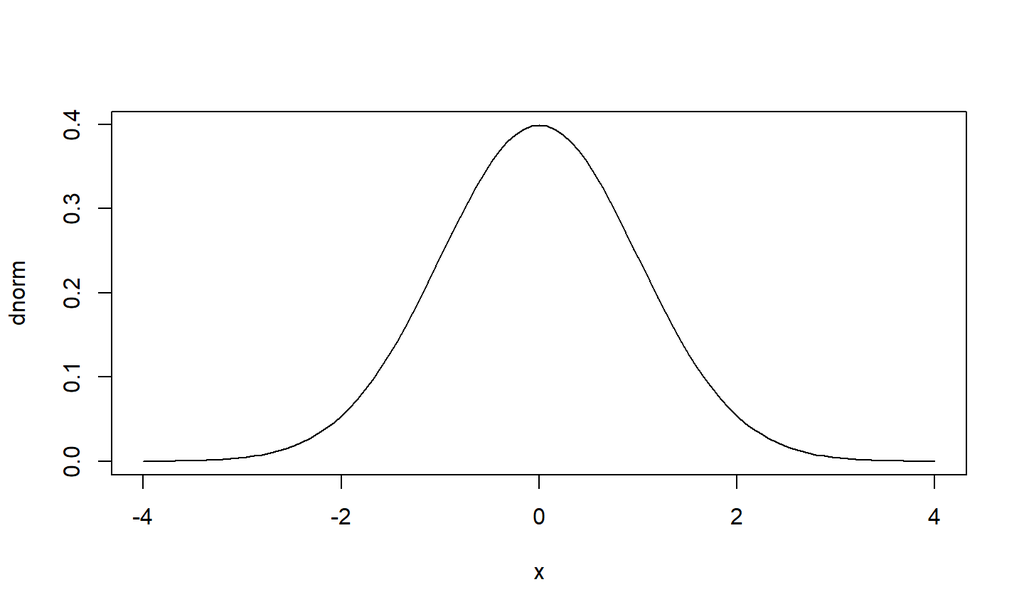

```r
plot(dnorm, -4, 4)
```

## Distribuição Normal

Gráfico da função probabilidade acumulada:

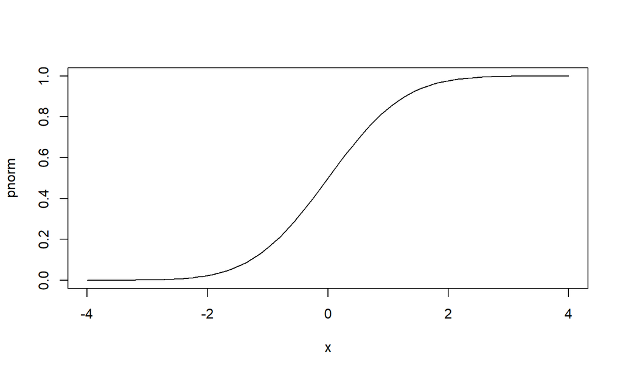

```r
plot(pnorm, -4, 4)
```

## Distribuição Binomial

A distribuição binomial é adequada para descrever situações em que os resultados de uma variável aleatória podem ser agrupados em apenas duas classes ou categorias.

As categorias devem ser mutuamente excludentes, de forma que não haja dúvidas na classificação do resultado da variável nas categorias e coletivamente exaustivas, de forma que não seja possível nenhum outro resultado diferente das categorias.

Para a realização de cálculos no R com a distribuição binomial, devemos combinar as letras básicas com o termo binom.

## Distribuição Binomial

Em uma distribuição discreta de probabilidades os gráficos são diferentes dos obtidos para distribuição normal e os cálculos de probabilidades devem considerar as probabilidades nos pontos.

## Distribuição Binomial

Gráfico da função densidade Binomial

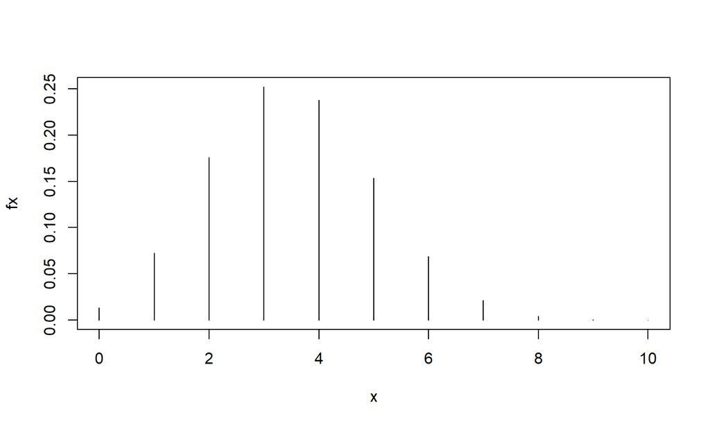

```r
x <- 0:10
fx <- dbinom(x, 10, 0.35)
plot(x, fx, type='h')
```

## Distribuição Binomial

Gráfico da função probabilidade Binomial

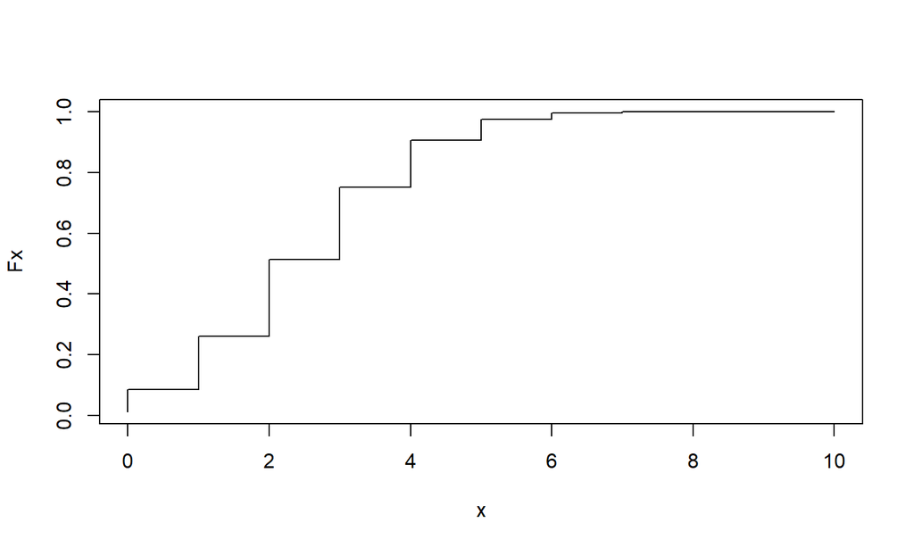

```r
x <- 0:10
Fx <- pbinom(x, 10, 0.35)
plot(x, Fx, type='S')
```

## Outras distribuições

- Uniforme contínua: runif, punif, dunif, qunif;
- Poisson: rpois, …
- Outras distribuições: dbeta, dcauchy, dchisq, dexp, df, dgamma, dgeom, dlnorm, dmultinom, dnbinom, dt, dweibull.